# Implementing the BYM2 Model in Stan

### The BYM2 Model: Riebler et al, 2016

The ICAR model assumes complete spatial correlation between regions. This simplifying assumption makes it cheap to compute; the CAR model, which adds a weight to each neighbor pair to account for the strength of the spatial correlation, requires computing the inverse of the adjacency matrix, an cubic operation. For maps with more than a handful of regions, this is prohibitively expensive, computationally. The Besag York Mollié (BYM) model was developed to address this problem; the BYM2 model builds on this model and subsequent refinements.

- Poisson regression + component for extra variation which combines spatial and non-spatial components $\phi + \theta$ as
  $$\left( (\sqrt{\, {\rho} / s}\, \ )\,\phi^* + (\sqrt{1-\rho})\,\theta^* \right) \sigma$$
  where:
  - $\sigma\geq 0$ is the overall standard deviation.
  - $\rho \in [0,1]$ - proportion of spatial variance.
  - $\phi^*$ is the ICAR component.
  - $\theta^* \sim N(0, 1)$ is the vector of ordinary random effects
  - $s$ is a scaling factor s.t. $\operatorname{Var}(\phi_i) \approx 1$; $s$ is data.
- Follows previous BYM modifications, notably Leroux 2000, which has a single scale parameter plus mixing parameter.
- Adds a scaling factor on the ICAR component so that for each element $i$ in vectors $\theta$ and $\phi$, $\operatorname{Var}(\theta_i) \approx \operatorname{Var}(\phi_i) \approx 1$. The scaling factor is derived from the adjacency matrix (neighbors graph).

## Notebook Setup

### Libraries and helper functions.

**Python**

```python
# import all libraries used in this notebook
import os
import numpy as np
import pandas as pd
import geopandas as gpd
import libpysal
import matplotlib
from splot.libpysal import plot_spatial_weights
%matplotlib inline

from cmdstanpy import CmdStanModel, cmdstan_path, cmdstan_version

import warnings
warnings.filterwarnings('ignore')
from utils_bym2 import get_scaling_factor, nbs_to_adjlist
from utils_dataviz import *
```

**R**

````markdown
```{r}
library(ggplot2)
library(igraph)
library(Matrix)
library(parallel)
library(sf)
library(spdep) |> suppressPackageStartupMessages()
library(tidyverse) |> suppressPackageStartupMessages()

library(cmdstanr)
library(posterior)
library(bayesplot)
library(loo)
cores = floor(parallel::detectCores() / 2)
source("utils_bym2.R")
source("utils_dataviz.R")
```
````

### Load NYC Dataset

**Python**

```python
nyc_geodata = gpd.read_file(os.path.join('..', 'data', 'nyc_study.geojson'))
nyc_geodata.columns
```

```
Index(['CTLabel', 'BoroCode', 'BoroName', 'CT2010', 'BoroCT2010', 'CDEligibil',
       'NTACode', 'NTAName', 'PUMA', 'Shape_Leng', 'Shape_Area', 'BoroFips',
       'ct2010full', 'kids_per_sq_mi', 'count', 'kid_pop', 'pct_pubtransit',
       'med_hh_inc', 'traffic', 'frag_index', 'geometry'],
      dtype='object')
```

**R**

````markdown
```{r}
nyc_geodata = st_read(file.path('..', 'data', 'nyc_study.geojson'))
names(nyc_geodata)
```
````

## New York City Neighbor Graph

New York city consists of several islands; only the Bronx is part of the mainland; Brooklyn and Queens are part of Long Island, plus smaller islands City Island, Roosevelt Island, and the Rockaways.

*This is a problem for the ICAR model, which operates on a fully connected graph (single component)*

**Python**

```python
w_nyc_nbs = libpysal.weights.Queen.from_dataframe(nyc_geodata, geom_col='geometry')
print(f'number of components: {w_nyc_nbs.n_components}')
print(f'islands? {w_nyc_nbs.islands}')
print(f'max number of neighbors per node: {w_nyc_nbs.max_neighbors}')
print(f'mean number of neighbors per node: {w_nyc_nbs.mean_neighbors}')
```

```
number of components: 8
islands? [328, 1860, 1903]
max number of neighbors per node: 14
mean number of neighbors per node: 5.891169451073986
```

**R**

````markdown
```{r}
nyc_nbs = poly2nb(nyc_geodata)
summary(nyc_nbs)
table(n.comp.nb(nyc_nbs)$comp.id)
```
````

- For the NYC analysis paper, we hand edited the map of NYC (in R) to create a fully connected network graph.
- For this notebook we restrict our attention to Brooklyn, the largest borough in NYC, which is a single network component.

**Python**

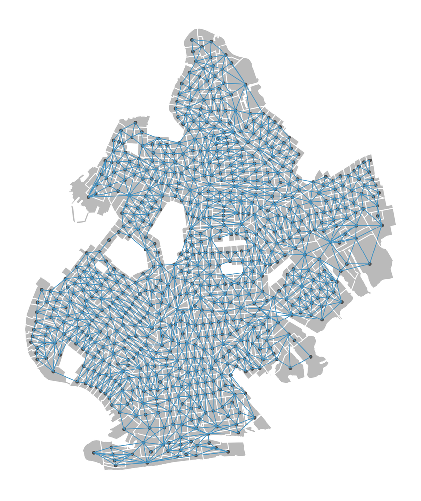

```python
brooklyn_geodata = nyc_geodata[nyc_geodata['BoroName']=='Brooklyn'].reset_index(drop=True)
brooklyn_nbs = libpysal.weights.Queen.from_dataframe(brooklyn_geodata, geom_col='geometry')
plot_spatial_weights(brooklyn_nbs, brooklyn_geodata)
```

```python
print(f'number of components: {brooklyn_nbs.n_components}')
print(f'islands? {brooklyn_nbs.islands}')
print(f'max number of neighbors per node: {brooklyn_nbs.max_neighbors}')
print(f'mean number of neighbors per node: {brooklyn_nbs.mean_neighbors}')
```

```
number of components: 1
islands? []
max number of neighbors per node: 13
mean number of neighbors per node: 6.029530201342282
```

**R**

````markdown
```{r}
brooklyn_geodata = nyc_geodata[nyc_geodata$BoroName=='Brooklyn', ]
brooklyn_nbs = poly2nb(brooklyn_geodata)
brooklyn_coords = st_coordinates(st_centroid(brooklyn_geodata['geometry']))
plot(st_geometry(brooklyn_geodata), col='skyblue')
plot(brooklyn_nbs, coords=brooklyn_coords, add=TRUE, pch=20, cex=0.6)
```
````

````markdown
```{r}
summary(brooklyn_nbs)
```
````

## From ICAR to BYM2

- The BYM2 model combines both ICAR component $\phi$ and ordinary random effects $\theta$ as
  $$\left( (\sqrt{\, {\rho} / s}\, \ )\,\phi^* + (\sqrt{1-\rho})\,\theta^* \right) \sigma$$
- Parameter $\rho$ answers the question: how much of the observed variance is spatial?
- Don’t need to run analysis, e.g. Moran’s I - the model sorts it out for you.

## BYM2 Model: `bym2.stan`

This file is in directory `stan/bym2.stan`.

**Python**

```python
bym2_model_file = os.path.join('..', 'stan', 'bym2.stan')

with open(bym2_model_file, 'r') as file:
    contents = file.read()
    print(contents)
```

```
data {
  int<lower=0> N;
  array[N] int<lower=0> y; // count outcomes
  vector<lower=0>[N] E; // exposure
  int<lower=1> K; // num covariates
  matrix[N, K] xs; // design matrix

  // spatial structure
  int<lower = 0> N_edges;  // number of neighbor pairs
  array[2, N_edges] int<lower = 1, upper = N> neighbors;  // columnwise adjacent

  real tau; // scaling factor
}
transformed data {
  vector[N] log_E = log(E);
  // center continuous predictors
  vector[K] means_xs;  // column means of xs before centering
  matrix[N, K] xs_centered;  // centered version of xs
  for (k in 1:K) {
    means_xs[k] = mean(xs[, k]);
    xs_centered[, k] = xs[, k] - means_xs[k];
  }
}
parameters {
  real beta0; // intercept
  vector[K] betas; // covariates
  real<lower=0, upper=1> rho; // proportion of spatial variance
  sum_to_zero_vector[N] phi;  // spatial effects
  vector[N] theta; // heterogeneous random effects
  real<lower = 0> sigma;  // scale of combined effects
}
transformed parameters {
  vector[N] gamma = sqrt(1 - rho) * theta + sqrt(rho * inv(tau)) * phi;  // BYM2
}
model {
  y ~ poisson_log(log_E + beta0 + xs_centered * betas + gamma * sigma);
  rho ~ beta(0.5, 0.5);
  target += -0.5 * dot_self(phi[neighbors[1]] - phi[neighbors[2]]); // ICAR prior
  beta0 ~ std_normal();
  betas ~ std_normal();
  theta ~ std_normal();
  sigma ~ std_normal();
}
generated quantities {
  real beta_intercept = beta0 - dot_product(means_xs, betas);  // adjust intercept
  array[N] int y_rep;
  {
    vector[N] eta = log_E + beta0 + xs_centered * betas + gamma * sigma;
    y_rep = max(eta) < 26 ? poisson_log_rng(eta) : rep_array(-1, N);
  }
}
```

**R**

````markdown
```{r}
bym2_model_file = file.path('..', 'stan', 'bym2.stan')
cat(readLines(bym2_model_file), sep="\n")
```
````

## Preparing the data inputs

### Get edgeset

- Compute this automatically from `nyc_geodata` spatial geometry component
  - Python package `libpysal`
  - R package `spdep`

**Python**

```python
brooklyn_nbs_adj = nbs_to_adjlist(brooklyn_nbs)
brooklyn_nbs_adj
```

```
array([[  1,   1,   1, ..., 739, 740, 741],
       [  3,   4,   5, ..., 742, 742, 742]])
```

**R**

````markdown
```{r}
brooklyn_nbs_adj = nbs_to_adjlist(brooklyn_nbs)
brooklyn_nbs_adj[1:2, 1:10]
```
````

### Compute scaling factor `tau`

The BYM2 model component gamma combines an vector of non-spatial random effects `theta`, and the vector of spatial random effects `phi`. The prior on `theta` is `std_normal()` thus the its variance is approximately $1$. The prior on `phi` is the ICAR component, the spatial covariance matrix. To make the variance of the `phi` be approximately $1$, Riebler et. al. recommend scaling it by the geometric mean of the variance of the spatial adjacency matrix. This quantity is `tau`, and is computed by helper function `get_scaling_factor`.

**Python**

```python
tau = get_scaling_factor(brooklyn_nbs)
tau
```

```
0.5082442939055537
```

**R**

````markdown
```{r}
tau = get_scaling_factor(brooklyn_nbs)
tau
```
````

#### Assemble the input data

**Python**

```python
design_vars = np.array(['pct_pubtransit','med_hh_inc', 'traffic', 'frag_index'])

design_mat = brooklyn_geodata[design_vars].to_numpy()
design_mat[:, 1] = np.log(design_mat[:, 1])
design_mat[:, 2] = np.log(design_mat[:, 2])

pd.DataFrame(data=design_mat).describe()
```

|  | 0 | 1 | 2 | 3 |
| --- | --- | --- | --- | --- |
| count | 745.000000 | 745.000000 | 745.000000 | 745.000000 |
| mean | 0.743001 | 10.786729 | 9.906006 | -0.216161 |
| std | 0.136709 | 0.435962 | 0.815884 | 2.008809 |
| min | 0.228300 | 9.362289 | 7.074117 | -5.696500 |
| 25% | 0.652600 | 10.537628 | 9.361945 | -1.593300 |
| 50% | 0.766100 | 10.768885 | 9.784310 | -0.193700 |
| 75% | 0.850200 | 11.096561 | 10.289056 | 1.150200 |
| max | 1.000000 | 12.226880 | 12.108487 | 6.688900 |

```python
bym2_data = {"N":brooklyn_geodata.shape[0],
             "y":brooklyn_geodata['count'].astype('int'),
             "E":brooklyn_geodata['kid_pop'].astype('int'),
             "K":4,
             "xs":design_mat,
             "N_edges": brooklyn_nbs_adj.shape[1],
             "neighbors": brooklyn_nbs_adj,
         "tau": tau
}
```

**R**

````markdown
```{r}
design_mat <- as.data.frame(brooklyn_geodata) %>%
  select(pct_pubtransit, med_hh_inc, traffic, frag_index) %>%
  mutate(med_hh_inc = log(med_hh_inc),
         traffic = log(traffic))
summary(design_mat)
```
````

````markdown
```{r}
bym2_data <- list(
  N = nrow(brooklyn_geodata),
  y = as.integer(brooklyn_geodata$count),
  E = as.integer(brooklyn_geodata$kid_pop),
  K = 4,
  xs = design_mat,
  N_edges = ncol(brooklyn_nbs_adj),
  neighbors = brooklyn_nbs_adj,
  tau = tau
)
```
````

## Workflow: Prior Predictive Checking

Prior and posterior predictive checks are two cases of the general concept of predictive checks, just conditioning on different things (no data and the observed data, respectively). Posteior predictive checks were introduced in the Stan model building workflow notebook, which shows how to generate a new dataset (`y_rep`) in the generated quantities block based on the sample estimate of the model parameters. Comparison of the replicated datasets with the observed datasets shows how well or poorly the model captures the essential characteristics of the data.

[Prior predictive checks](https://mc-stan.org/docs/stan-users-guide/posterior-predictive-checks.html#prior-predictive-checks) simulate data directly from the prior, in the absense of any observed data. The resulting datasets, often called `y_sim`, instead of `y_rep`, show the possible range of data that is consistent with the priors. This can be used to diagnose priors which are too strong or too weak.

The Stan User’s Guide shows [how to code](https://mc-stan.org/docs/stan-users-guide/posterior-predictive-checks.html#prior-predictive-checks) in order to check all priors. Unlike posterior predictive checks, in order to efficiently do the simulation, it is necessary to rewrite the model. In this notebook, we only want to verify that the BYM2 model does in fact properly scale the variance of `phi`, so we only need to simulate the convolved spatial and random effects component `gamma`, which will allow us to check `theta`, `phi`, and `rho`.

### Checking effect of scaling `phi` by `tau`.

To examine the effect of the scaling factor, we simulate the parameters `gamma`, `phi`, `theta`, and `rho` using a simplified version of the model that excludes both the observed data (`y` and `xs`) and the Poisson regression component. This allows us to assess the resulting priors on `phi`, `theta`, and `rho` *before incorporating any data*.

**Python**

```python
bym2_gamma_ppc_file = os.path.join('..', 'stan', 'bym2_gamma_ppc.stan')
with open(bym2_gamma_ppc_file, 'r') as file:
    contents = file.read()
    print(contents)
```

```
data {
  int<lower=0> N;
  // spatial structure
  int<lower = 0> N_edges;  // number of neighbor pairs
  array[2, N_edges] int<lower = 1, upper = N> neighbors;  // columnwise adjacent

  real tau; // scaling factor
}
parameters {
  real<lower=0, upper=1> rho; // proportion of spatial variance
  sum_to_zero_vector[N] phi;  // spatial effects
  vector[N] theta; // heterogeneous random effects
  real<lower = 0> sigma;  // scale of combined effects
}
transformed parameters {
  vector[N] gamma = sqrt(1 - rho) * theta + sqrt(rho * inv(tau)) * phi;  // BYM2
}
model {
  rho ~ beta(0.5, 0.5);
  target += -0.5 * dot_self(phi[neighbors[1]] - phi[neighbors[2]]); // ICAR prior
  theta ~ std_normal();
  sigma ~ std_normal();
}
```

**R**

````markdown
```{r}
bym2_gamma_ppc_file = file.path('..', 'stan', 'bym2_gamma_ppc.stan')
cat(readLines(bym2_gamma_ppc_file), sep="\n")
```
````

#### Model compilation

**Python**

```python
bym2_gamma_ppc_mod = CmdStanModel(stan_file=bym2_gamma_ppc_file)
```

**R**

````markdown
```{r}
bym2_gamma_ppc_mod = cmdstan_model(stan_file=bym2_gamma_ppc_file)
```
````

#### Run model, check variances

In the BYM2 model, phi is scaled by the square root of $1$/`tau` since the ICAR component `phi` follows a multivariate normal distribution with covariance matrix $\Sigma$, whereas `theta` is a vector of standard normal variables.

**Python**

```python
bym2_gamma_ppc_fit = bym2_gamma_ppc_mod.sample(data = bym2_data)
```

```
09:41:13 - cmdstanpy - INFO - CmdStan start processing
```

```
09:41:17 - cmdstanpy - INFO - CmdStan done processing.
```

```python
phi = bym2_gamma_ppc_fit.stan_variable('phi')  # shape (n_draws, N)
phi_var_by_region = np.var((np.sqrt(1/tau) * phi), axis=0)  # variance across draws for each region
print('mean variance of phi scaled', np.mean(phi_var_by_region))

theta = bym2_gamma_ppc_fit.stan_variable('theta')  # shape (n_draws, N)
print('mean variance of theta', np.mean(np.var(theta, axis=0)))
```

```
mean variance of phi scaled 1.0558835007676686
mean variance of theta 0.9997272228327427
```

**R**

````markdown
```{r}
bym2_gamma_ppc_fit = bym2_gamma_ppc_mod$sample(data=bym2_data, parallel_chains=cores, refresh=0)
```
````

````markdown
```{r}
phi <- as_draws_matrix(bym2_gamma_ppc_fit$draws("phi"))
phi_var_by_region <- apply(sqrt(1/tau) * phi, 2, var)  # variance across draws for each region
print(paste("mean variance of phi scaled:", mean(phi_var_by_region)))
theta <- as_draws_matrix(bym2_gamma_ppc_fit$draws("theta"))
theta_var_by_region <- apply(theta, 2, var)  # variance across draws for each region
print(paste("mean variance of theta:", mean(theta_var_by_region)))
```
````

#### Check `rho`

The fitted model also provides an estimate of `rho`, which has prior

```stan
rho ~ beta(0.5, 0.5);
```

As expected, before seeing any data, the value of `rho` matches the prior.

**Python**

```python
rho = bym2_gamma_ppc_fit.stan_variable('rho')
print('mean rho', np.mean(rho))
```

```
mean rho 0.5010041388340606
```

**R**

````markdown
```{r}
rho <- as_draws_array(bym2_gamma_ppc_fit$draws("rho"))
mean(rho)
```
````

### Comparison with the Leroux model

When the scaling factor `tau` is 1.0, the BYM2 model is equivalent to the Leroux model, and in this case, we can compute the variance of phi directly.

**Python**

```python
print('mean variance of phi', np.mean(np.var(phi, axis=0)))
```

```
mean variance of phi 0.5366467642941878
```

**R**

````markdown
```{r}
print(paste("mean variance of phi:", mean(apply(phi, 2, var))))
```
````

## Fitting the BYM2 Model on the Brooklyn data

#### Model is compiled (as needed) on instantiation

**Python**

```python
bym2_mod = CmdStanModel(stan_file=bym2_model_file)
```

**R**

````markdown
```{r}
bym2_mod = cmdstan_model(stan_file=bym2_model_file)
```
````

#### Run the NUTS-HMC sampler, summarize results

**Python**

```python
bym2_fit = bym2_mod.sample(data=bym2_data)

bym2_summary = bym2_fit.summary()
bym2_summary.round(2).loc[
  ['beta_intercept', 'beta0', 'betas[1]', 'betas[2]', 'betas[3]', 'betas[4]', 'sigma', 'rho']]
```

```
09:41:18 - cmdstanpy - INFO - CmdStan start processing
```

```
09:41:25 - cmdstanpy - INFO - CmdStan done processing.
```

|  | Mean | MCSE | StdDev | MAD | 5% | 50% | 95% | ESS_bulk | ESS_tail | R_hat |
| --- | --- | --- | --- | --- | --- | --- | --- | --- | --- | --- |
| beta_intercept | -9.27 | 0.05 | 1.14 | 1.13 | -11.12 | -9.26 | -7.44 | 529.93 | 1184.33 | 1.00 |
| beta0 | -4.27 | 0.00 | 0.03 | 0.03 | -4.31 | -4.27 | -4.22 | 1993.70 | 2302.69 | 1.00 |
| betas[1] | 1.07 | 0.01 | 0.35 | 0.36 | 0.47 | 1.07 | 1.63 | 663.01 | 1112.05 | 1.00 |
| betas[2] | 0.27 | 0.00 | 0.09 | 0.09 | 0.13 | 0.27 | 0.42 | 530.60 | 1103.17 | 1.00 |
| betas[3] | 0.13 | 0.00 | 0.04 | 0.04 | 0.07 | 0.13 | 0.19 | 1494.20 | 2122.24 | 1.00 |
| betas[4] | 0.04 | 0.00 | 0.02 | 0.02 | 0.01 | 0.04 | 0.08 | 1154.79 | 1821.74 | 1.00 |
| sigma | 0.69 | 0.00 | 0.03 | 0.03 | 0.64 | 0.69 | 0.75 | 360.44 | 744.77 | 1.01 |
| rho | 0.33 | 0.01 | 0.09 | 0.10 | 0.19 | 0.33 | 0.49 | 144.13 | 387.18 | 1.03 |

**R**

````markdown
```{r}
bym2_fit = bym2_mod$sample(data=bym2_data, parallel_chains=cores, refresh=0)
bym2_fit$print(variables = c('beta_intercept', 'beta0', 'betas[1]', 'betas[2]', 'betas[3]', 'betas[4]', 'sigma', 'rho'))
```
````

## Model Checking

### Visualizing the ICAR component

**Python**

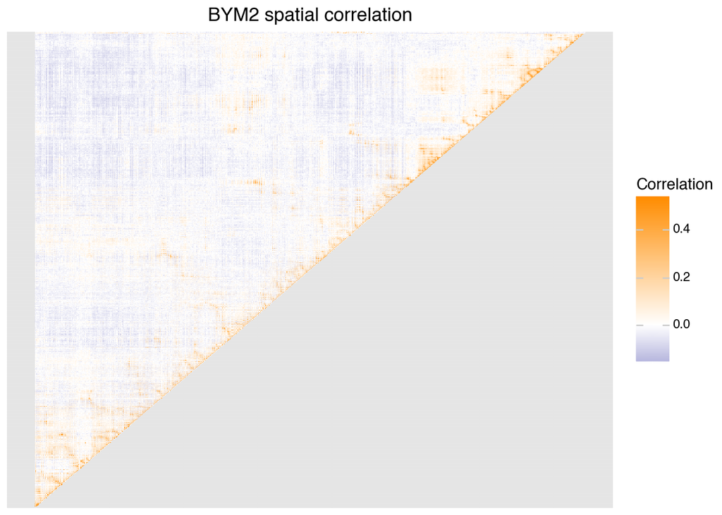

```python
phi_bym2 = bym2_fit.stan_variable("phi")
corr_plot = plot_icar_corr_matrix(phi_bym2, 'BYM2 spatial correlation', (10, 10))
corr_plot
```

**R**

````markdown
```{r}
phi_bym2 <- as_draws_matrix(bym2_fit$draws("phi"))
plot_icar_corr_matrix(phi_bym2, 'BYM2 spatial correlation')
```
````

##### Comparison to simple ICAR model

**Python**

```
09:41:38 - cmdstanpy - INFO - CmdStan start processing
```

```
09:41:42 - cmdstanpy - INFO - CmdStan done processing.
```

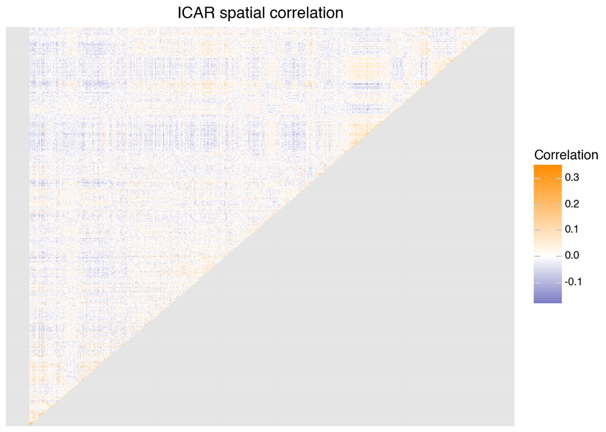

```python
pois_icar_mod = CmdStanModel(stan_file=os.path.join('..', 'stan', 'poisson_icar.stan'))
pois_icar_fit = pois_icar_mod.sample(data=bym2_data)
phi_icar = pois_icar_fit.stan_variable("phi")
corr_plot = plot_icar_corr_matrix(phi_icar, 'ICAR spatial correlation', (10, 10))
corr_plot
```

**R**

````markdown
```{r}
pois_icar_mod = cmdstan_model(stan_file=file.path('..', 'stan', 'poisson_icar.stan'))
pois_icar_fit = pois_icar_mod$sample(data=bym2_data, parallel_chains=cores, refresh=0)
phi_icar <- as_draws_matrix(pois_icar_fit$draws("phi"))
plot_icar_corr_matrix(phi_icar, 'ICAR spatial correlation')
```
````

Compared to the covariance matrix of `phi` for the BYM2 model, the spatial correlations are less sharp, i.e. the addition of component `theta` allows `phi` to more strongly identify the spatial correlation structure of the data.

## Model Comparison: BYM2 vs Poisson + ICAR vs. Poisson + RE

#### Poisson + ICAR model

**Python**

```python
pois_icar_summary = pois_icar_fit.summary()
pois_icar_summary.round(2).loc[
  ['beta_intercept', 'beta0', 'betas[1]', 'betas[2]', 'betas[3]', 'betas[4]', 'sigma']]
```

|  | Mean | MCSE | StdDev | MAD | 5% | 50% | 95% | ESS_bulk | ESS_tail | R_hat |
| --- | --- | --- | --- | --- | --- | --- | --- | --- | --- | --- |
| beta_intercept | -10.49 | 0.05 | 1.16 | 1.17 | -12.40 | -10.51 | -8.59 | 483.76 | 784.26 | 1.01 |
| beta0 | -4.27 | 0.00 | 0.02 | 0.02 | -4.30 | -4.27 | -4.25 | 3503.94 | 3183.33 | 1.00 |
| betas[1] | 0.99 | 0.02 | 0.36 | 0.37 | 0.41 | 0.98 | 1.59 | 548.42 | 993.15 | 1.00 |
| betas[2] | 0.37 | 0.00 | 0.09 | 0.09 | 0.22 | 0.37 | 0.53 | 530.82 | 1183.29 | 1.00 |
| betas[3] | 0.15 | 0.00 | 0.04 | 0.04 | 0.09 | 0.15 | 0.22 | 717.84 | 1325.39 | 1.01 |
| betas[4] | 0.05 | 0.00 | 0.02 | 0.02 | 0.02 | 0.05 | 0.09 | 564.60 | 1370.86 | 1.00 |
| sigma | 1.42 | 0.00 | 0.06 | 0.06 | 1.33 | 1.43 | 1.52 | 775.36 | 1669.76 | 1.00 |

**R**

````markdown
```{r}
pois_icar_fit$print(variables = c('beta_intercept', 'beta0', 'betas[1]', 'betas[2]', 'betas[3]', 'betas[4]', 'sigma'))
```
````

#### Poisson + RE model

**Python**

```python
pois_re_mod = CmdStanModel(stan_file=os.path.join('..', 'stan', 'poisson_re.stan'))
pois_re_fit = pois_re_mod.sample(data=bym2_data)
pois_re_summary = pois_re_fit.summary()
pois_re_summary.round(2).loc[
  ['beta_intercept', 'beta0', 'betas[1]', 'betas[2]', 'betas[3]', 'betas[4]', 'sigma']]
```

```
09:41:50 - cmdstanpy - INFO - CmdStan start processing
```

```
09:41:53 - cmdstanpy - INFO - CmdStan done processing.
```

|  | Mean | MCSE | StdDev | MAD | 5% | 50% | 95% | ESS_bulk | ESS_tail | R_hat |
| --- | --- | --- | --- | --- | --- | --- | --- | --- | --- | --- |
| beta_intercept | -6.56 | 0.03 | 0.82 | 0.81 | -7.87 | -6.57 | -5.21 | 867.98 | 1522.39 | 1.00 |
| beta0 | -4.26 | 0.00 | 0.03 | 0.03 | -4.31 | -4.26 | -4.21 | 761.24 | 1760.95 | 1.00 |
| betas[1] | 0.78 | 0.01 | 0.27 | 0.28 | 0.33 | 0.78 | 1.22 | 783.43 | 1267.54 | 1.01 |
| betas[2] | 0.08 | 0.00 | 0.07 | 0.07 | -0.03 | 0.09 | 0.19 | 787.96 | 1487.86 | 1.00 |
| betas[3] | 0.08 | 0.00 | 0.04 | 0.04 | 0.03 | 0.08 | 0.14 | 738.95 | 1264.54 | 1.00 |
| betas[4] | 0.05 | 0.00 | 0.02 | 0.02 | 0.02 | 0.05 | 0.08 | 742.57 | 1174.62 | 1.00 |
| sigma | 0.67 | 0.00 | 0.02 | 0.02 | 0.63 | 0.67 | 0.71 | 979.79 | 1945.24 | 1.01 |

**R**

````markdown
```{r}
pois_re_mod = cmdstan_model(stan_file=file.path('..', 'stan', 'poisson_re.stan'))
pois_re_fit = pois_re_mod$sample(data=bym2_data, parallel_chains=cores, refresh=0)
pois_re_fit$print(variables = c('beta_intercept', 'beta0', 'betas[1]', 'betas[2]', 'betas[3]', 'betas[4]', 'sigma'))
```
````

### Compare overall variance

In the these models `sigma` determines the overall magnitude of variation in the combined spatial (`phi`) and non-spatial(`theta`) random effects. The BYM2 model adds parameter `rho`, the proportion of variance which is spatially structured.

**Python**

```python
print('BYM2')
print(bym2_summary.round(2).loc[['sigma', 'rho']])

print('\nPoisson ICAR')
print(pois_icar_summary.round(2).loc[['sigma']])

print('\nPoisson Ordinary random effects')
print(pois_re_summary.round(2).loc[['sigma']])
```

```
BYM2
       Mean  MCSE  StdDev   MAD    5%   50%   95%  ESS_bulk  ESS_tail  R_hat
sigma  0.69  0.00    0.03  0.03  0.64  0.69  0.75    360.44    744.77   1.01
rho    0.33  0.01    0.09  0.10  0.19  0.33  0.49    144.13    387.18   1.03

Poisson ICAR
       Mean  MCSE  StdDev   MAD    5%   50%   95%  ESS_bulk  ESS_tail  R_hat
sigma  1.42   0.0    0.06  0.06  1.33  1.43  1.52    775.36   1669.76    1.0

Poisson Ordinary random effects
       Mean  MCSE  StdDev   MAD    5%   50%   95%  ESS_bulk  ESS_tail  R_hat
sigma  0.67   0.0    0.02  0.02  0.63  0.67  0.71    979.79   1945.24   1.01
```

**R**

````markdown
```{r}
cat("BYM2")
bym2_fit$print(variables = c('sigma', 'rho'))

cat("Poisson ICAR")
pois_icar_fit$print(variables = c('sigma'))

cat("Poisson Ordinary Random Effects")
pois_re_fit$print(variables = c('sigma'))
```
````

### Compare Posterior predictive check coverage

**Python**

```python
y_rep_bym2 = bym2_fit.stan_variable("y_rep")
print("PPC BYM2\n", ppc_central_interval(y_rep_bym2, bym2_data['y']))

y_rep_icar = pois_icar_fit.stan_variable("y_rep")
print("PPC Poisson + ICAR\n", ppc_central_interval(y_rep_icar, bym2_data['y']))

y_rep_re = pois_re_fit.stan_variable("y_rep")
print("PPC Poisson + RE\n", ppc_central_interval(y_rep_re, bym2_data['y']))
```

```
PPC BYM2
 y total: 745, ct y is within y_rep central 50% interval: 713, pct: 95.70469798657719
PPC Poisson + ICAR
 y total: 745, ct y is within y_rep central 50% interval: 698, pct: 93.69127516778524
PPC Poisson + RE
 y total: 745, ct y is within y_rep central 50% interval: 716, pct: 96.10738255033557
```

**R**

````markdown
```{r}
y_rep_bym2 <- as_draws_matrix(bym2_fit$draws("y_rep"))
cat("PPC BYM2")
ppc_central_interval(y_rep_bym2, bym2_data$y)

y_rep_icar <- as_draws_matrix(pois_icar_fit$draws("y_rep"))
cat("PPC Poisson + ICAR")
ppc_central_interval(y_rep_icar, bym2_data$y)

y_rep_re <- as_draws_matrix(pois_re_fit$draws("y_rep"))
cat("PPC Poisson + RE")
ppc_central_interval(y_rep_re, bym2_data$y)
```
````

### PPC plots

#### BYM2 model

**Python**

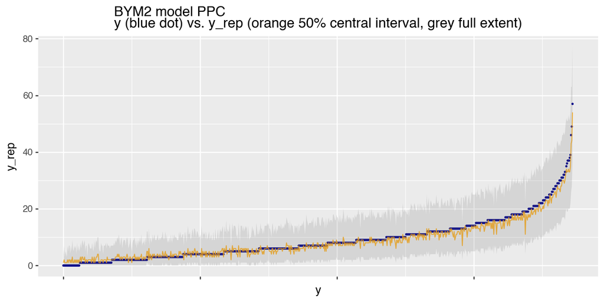

```python
ppc_plot = ppc_y_yrep_overlay(y_rep_bym2, bym2_data['y'],
                                'BYM2 model PPC\ny (blue dot) vs. y_rep (orange 50% central interval, grey full extent)')
ppc_plot
```

**R**

````markdown
```{r}
ppc_y_yrep_overlay(y_rep_bym2, bym2_data$y,
                     'BYM2 model PPC\ny (blue dot) vs. y_rep (orange 50% central interval, grey full extent)')
```
````

#### ICAR model

**Python**

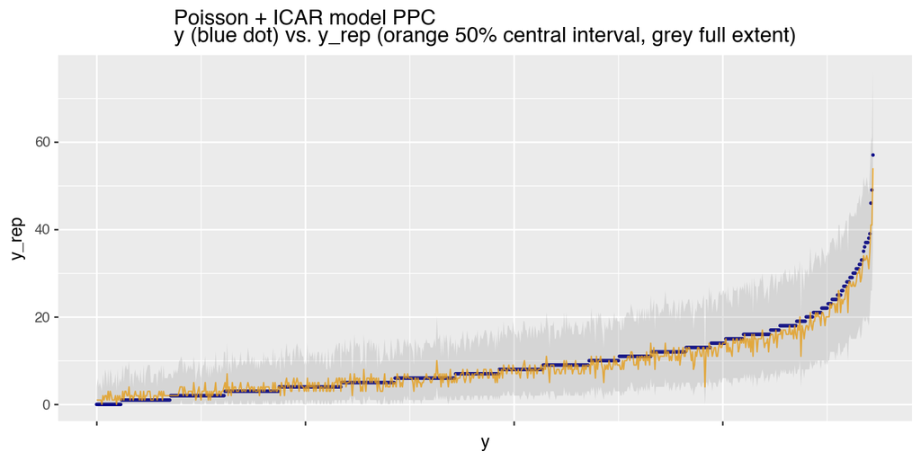

```python
ppc_plot = ppc_y_yrep_overlay(y_rep_icar, bym2_data['y'],
                                'Poisson + ICAR model PPC\ny (blue dot) vs. y_rep (orange 50% central interval, grey full extent)')
ppc_plot
```

**R**

````markdown
```{r}
ppc_y_yrep_overlay(y_rep_icar, bym2_data$y,
                     'Poisson + ICAR model PPC\ny (blue dot) vs. y_rep (orange 50% central interval, grey full extent)')
```
````

#### RE model

**Python**

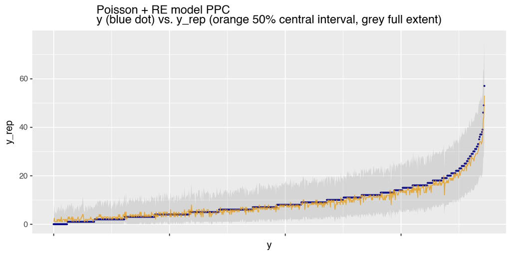

```python
ppc_plot = ppc_y_yrep_overlay(y_rep_re, bym2_data['y'],
                                'Poisson + RE model PPC\ny (blue dot) vs. y_rep (orange 50% central interval, grey full extent)')
ppc_plot
```

**R**

````markdown
```{r}
ppc_y_yrep_overlay(y_rep_re, bym2_data$y,
                     'Poisson + RE model PPC\ny (blue dot) vs. y_rep (orange 50% central interval, grey full extent)')
```
````